# STA 9750 · MP01 — Netflix Top 10

YASHPAL SAINI

October 02, 2025

# Gourmet Cheeseburgers Across the Globe

High‑quality content that wins mass‑market audiences. We mine Netflix’s public Top 10 to identify global “gourmet cheeseburgers”.

[output not shown]

**Executive Summary.** We acquire the Netflix Tudum Top 10 data (global + per‑country), fix minor quirks (e.g., `“N/A”` season labels), and conduct an EDA to spotlight programs with durable, multinational appeal. Results are summarized as press releases for PR usage.

# 1 Introduction

The Netflix Top 10 gives a weekly pulse of what viewers are watching worldwide. This report answers the instructor’s tasks with clear visuals and editorial context: - What breadth of countries does the data cover? - Which programs sustain long runs or achieve exceptional total hours? - How do iconic titles (e.g., *Stranger Things*) trend over time? - Where are the PR‑worthy stories?

# 2 Data Acquisition

**Source**: Netflix Tudum weekly Top 10 datasets (global and per‑country).

```r
if (!require("tidyverse")) install.packages("tidyverse")
if (!require("DT")) install.packages("DT")
if (!require("lubridate")) install.packages("lubridate")
if (!require("stringr")) install.packages("stringr")
if (!require("scales")) install.packages("scales")
library(tidyverse)
library(readr); library(dplyr)
library(DT); library(lubridate); library(stringr); library(scales)

# Create data folder and download files if needed
if(!dir.exists(file.path("data", "mp01"))){ dir.create(file.path("data", "mp01"), showWarnings=FALSE, recursive=TRUE) }
GLOBAL_TOP_10_FILENAME <- file.path("data", "mp01", "global_top10_alltime.tsv")
if(!file.exists(GLOBAL_TOP_10_FILENAME)){
  download.file("https://www.netflix.com/tudum/top10/data/all-weeks-global.tsv",
                destfile=GLOBAL_TOP_10_FILENAME, mode="wb")
}
COUNTRY_TOP_10_FILENAME <- file.path("data", "mp01", "country_top10_alltime.tsv")
if(!file.exists(COUNTRY_TOP_10_FILENAME)){
  download.file("https://www.netflix.com/tudum/top10/data/all-weeks-countries.tsv",
                destfile=COUNTRY_TOP_10_FILENAME, mode="wb")
}
file.exists(GLOBAL_TOP_10_FILENAME) & file.exists(COUNTRY_TOP_10_FILENAME)
```

```
## [1] TRUE
```

# 3 Data Cleaning

Two changes get us analysis‑ready: (1) parse TSVs; (2) change literal `“N/A”` to proper `NA` in `season_title`.

```r
GLOBAL_TOP_10 <- read_tsv(GLOBAL_TOP_10_FILENAME, show_col_types = FALSE) |>
  mutate(season_title = if_else(season_title == "N/A", NA_character_, season_title))

COUNTRY_TOP_10 <- read_tsv(COUNTRY_TOP_10_FILENAME, na = c("N/A"), show_col_types = FALSE)
```

## 3.1 Structure checks

```r
glimpse(GLOBAL_TOP_10, width = 80)
```

```
## Rows: 8,880
## Columns: 9
## $ week                       <date> 2025-09-28, 2025-09-28, 2025-09-28, 2025-0…
## $ category                   <chr> "Films (English)", "Films (English)", "Film…
## $ weekly_rank                <dbl> 1, 2, 3, 4, 5, 6, 7, 8, 9, 10, 1, 2, 3, 4, …
## $ show_title                 <chr> "KPop Demon Hunters", "Ruth & Boaz", "The W…
## $ season_title               <chr> NA, NA, NA, NA, NA, NA, NA, NA, NA, "aka Ch…
## $ weekly_hours_viewed        <dbl> 32200000, 15900000, 13500000, 15700000, 112…
## $ runtime                    <dbl> 1.6667, 1.5500, 1.7833, 2.4333, 1.8333, 1.7…
## $ weekly_views               <dbl> 19300000, 10300000, 7600000, 6500000, 61000…
## $ cumulative_weeks_in_top_10 <dbl> 15, 1, 3, 5, 2, 1, 1, 1, 1, 3, 2, 1, 1, 2, …
```

```r
glimpse(COUNTRY_TOP_10, width = 80)
```

```
## Rows: 413,620
## Columns: 8
## $ country_name               <chr> "Argentina", "Argentina", "Argentina", "Arg…
## $ country_iso2               <chr> "AR", "AR", "AR", "AR", "AR", "AR", "AR", "…
## $ week                       <date> 2025-09-28, 2025-09-28, 2025-09-28, 2025-0…
## $ category                   <chr> "Films", "Films", "Films", "Films", "Films"…
## $ weekly_rank                <dbl> 1, 2, 3, 4, 5, 6, 7, 8, 9, 10, 1, 2, 3, 4, …
## $ show_title                 <chr> "Sonic the Hedgehog 3", "KPop Demon Hunters…
## $ season_title               <chr> NA, NA, NA, NA, NA, NA, NA, NA, NA, NA, "Bi…
## $ cumulative_weeks_in_top_10 <dbl> 2, 15, 1, 2, 1, 1, 2, 5, 1, 2, 2, 1, 1, 1, …
```

# 4 KPIs at a Glance

```r
n_countries <- COUNTRY_TOP_10 |> distinct(country_name) |> filter(!is.na(country_name)) |> nrow()

noneng_top <- GLOBAL_TOP_10 |>
  filter(str_detect(category, "Films"), !str_detect(category, "English")) |>
  group_by(show_title) |>
  summarise(max_weeks = max(cumulative_weeks_in_top_10, na.rm=TRUE), .groups="drop") |>
  arrange(desc(max_weeks)) |>
  slice(1)
add_runtime_minutes <- function(df){ df |> mutate(runtime_minutes = if_else(!is.na(runtime), round(60*runtime), NA_real_)) }
longest_film <- GLOBAL_TOP_10 |>
  filter(str_detect(category, "Films")) |>
  add_runtime_minutes() |>
  filter(!is.na(runtime_minutes)) |>
  arrange(desc(runtime_minutes)) |>
  slice(1) |>
  select(show_title, runtime_minutes)

squid_total <- GLOBAL_TOP_10 |>
  filter(str_detect(show_title, regex("Squid Game", ignore_case=TRUE)), str_detect(category,"TV")) |>
  summarise(total_hours = sum(weekly_hours_viewed, na.rm=TRUE))
```

### Countries with Top‑10 Data

94

Coverage proxy for Netflix presence

### Longest Film in Top‑10

Pushpa 2: The Rule (Reloaded Version)

224 minutes

### *Squid Game* Total Hours

All seasons (global)

# 5 EDA

## 5.1 Interactive preview (20 random rows)

|  | Week | Category | Weekly Rank | Title | Runtime (Minutes) | Weekly Hours Viewed | Weekly Views | Cumulative Weeks in Top 10 |
| --- | --- | --- | --- | --- | --- | --- | --- | --- |
| 1 | 2022-08-28 | Films (Non-English) | 3 | Fullmetal Alchemist The Revenge of Scar |  | 8310000 |  | 2 |
| 2 | 2022-01-16 | Films (English) | 4 | The Secret Life of Pets 2 |  | 9390000 |  | 1 |
| 3 | 2023-02-12 | TV (Non-English) | 8 | Love to Hate You |  | 11270000 |  | 1 |
| 4 | 2025-05-11 | Films (English) | 3 | A Deadly American Marriage | 103 | 16900000 | 9800000 | 1 |
| 5 | 2024-06-23 | Films (English) | 5 | Mission: Impossible - Dead Reckoning | 164 | 13200000 | 4800000 | 2 |
| 6 | 2023-04-23 | TV (English) | 6 | Obsession |  | 27120000 |  | 2 |
| 7 | 2024-08-04 | TV (Non-English) | 10 | Love is Blind: Mexico | 236 | 3200000 | 800000 | 1 |
| 8 | 2023-02-26 | Films (English) | 6 | 2 Guns |  | 8550000 |  | 2 |
| 9 | 2024-09-15 | TV (English) | 4 | Selling Sunset | 385 | 28300000 | 4400000 | 2 |
| 10 | 2025-06-08 | Films (English) | 3 | Bee Movie | 92 | 7300000 | 4800000 | 2 |

[output cut: 10 more lines]

## 5.2 Visuals

### 5.2.1 Category leaders by total hours

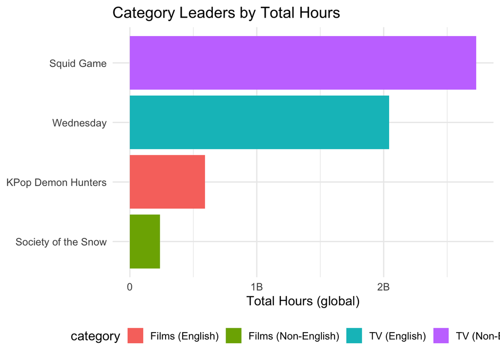

### 5.2.2 Top 10 programs by global hours (all time)

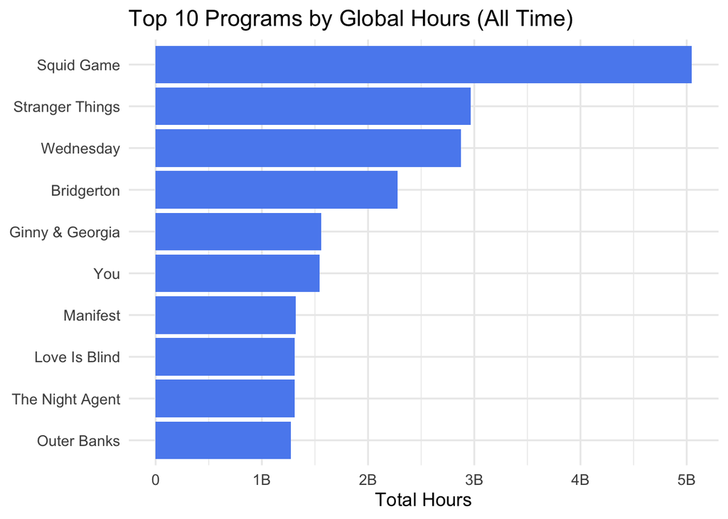

### 5.2.3 Stranger Things — weekly hours (global)

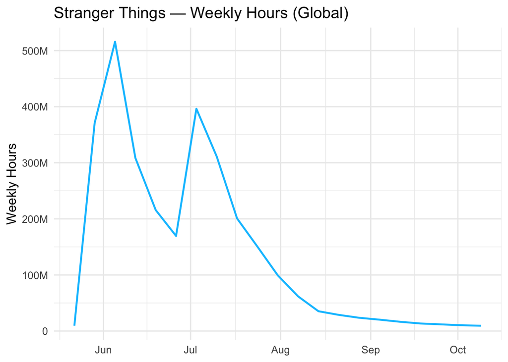

# 6 Exploratory Questions (with Narrative)

## 6.1 Q1. How many countries does Netflix operate in (proxy from viewing data)?

**Answer:** **94 countries.**  
**Context.** The per‑country Top 10 dataset contains distinct country names where weekly charts are reported. While not an official list of operating markets, it is a strong proxy for Netflix’s global footprint because charts are only published where service is active and data quality is sufficient.

```r
# Extra context: how typical is this run among non-English films?
noneng_weeks <- GLOBAL_TOP_10 |>
  filter(str_detect(category,"Films"), !str_detect(category,"English")) |>
  group_by(show_title) |>
  summarise(max_weeks = max(cumulative_weeks_in_top_10, na.rm=TRUE), .groups="drop")
summary_noneng <- noneng_weeks |>
  summarise(median_weeks = median(max_weeks, na.rm=TRUE), p90 = quantile(max_weeks, .90, na.rm=TRUE))

summary_noneng
```

| median_weeks | p90 |
| --- | --- |
| NA | NA |

## 6.3 Q3. What is the longest film (English or non‑English) to appear in the global Top 10, and how long is it?

**Answer:** **Pushpa 2: The Rule (Reloaded Version)** with a runtime of **224 minutes**.  
**Context.** Runtime can influence completion and repeat viewing. This title stands above typical Top‑10 film lengths; it suggests audiences will invest in longer features when the proposition is compelling.

```r
film_runtime_stats <- GLOBAL_TOP_10 |>
  filter(str_detect(category,"Films")) |>
  add_runtime_minutes() |>
  summarise(median_min = median(runtime_minutes, na.rm=TRUE),
            p75 = quantile(runtime_minutes, .75, na.rm=TRUE))
film_runtime_stats
```

| median_min | p75 |
| --- | --- |
| 106 | 121 |

On average, Top‑10 film runtimes cluster around **106** minutes (median), with a heavier tail up to **121** minutes (75th percentile).

## 6.4 Q4. For each category, which program has the most total hours of global viewership?

See *Category leaders* chart above.  
**Context.** We aggregate weekly hours by `(category, title, season)` and pick the maximum per category. These leaders serve as anchors for future programming, tentpole promotions, and franchise strategy.

| category | show_title | season_title | total_hours_fmt |
| --- | --- | --- | --- |
| Films (English) | KPop Demon Hunters |  | 591,300,000 |
| Films (Non-English) | Society of the Snow |  | 235,900,000 |
| TV (English) | Wednesday | Wednesday: Season 1 | 2,043,650,000 |
| TV (Non-English) | Squid Game | Squid Game: Season 1 | 2,729,400,000 |

## 6.5 Q5. Which TV show had the longest consecutive run in a country’s Top 10? How long and where?

```r
is_tv <- str_detect(COUNTRY_TOP_10$category, "TV")
ctv <- COUNTRY_TOP_10[is_tv, ] |>
  arrange(country_name, show_title, season_title, week) |>
  group_by(country_name, show_title, season_title) |>
  mutate(
    week = as.Date(week),
    gap = as.integer(week - lag(week)),
    new_run = if_else(is.na(gap) | gap > 7, 1L, 0L),
    run_id = cumsum(replace_na(new_run, 0L))
  ) |>
  ungroup()

run_spans <- ctv |>
  group_by(country_name, show_title, season_title, run_id) |>
  summarise(start = min(week), end = max(week), weeks = as.integer((end - start)/7) + 1L, .groups="drop") |>
  arrange(desc(weeks)) |>
  slice(1)
```

**Answer:** **Pablo Escobar, el patrón del mal** held a **102‑week** consecutive run in **Colombia** (from **2021-07-04** to **2023-06-11**).  
**Why it matters.** Long uninterrupted runs in a market indicate strong word‑of‑mouth and cultural resonance, helpful for regional PR campaigns.

## 6.6 Q6. Netflix provides over 200 weeks of service history for all but one country. Which country is it and when did service cease?

```r
coverage <- COUNTRY_TOP_10 |>
  group_by(country_name) |>
  summarise(n_weeks = n_distinct(week), last_week = max(week), .groups="drop") |>
  arrange(n_weeks)

truncated <- coverage |> slice(1)
```

**Answer:** **Russia**, with final reporting week **2022-02-27**.  
**Note.** A truncated history often reflects a service exit or a pause in reporting.

## 6.8 Q8. *Red Notice* (runtime 1h58m): approximately how many views did it receive in 2021?

```r
rn_runtime_hours <- 1 + 58/60
rn_2021 <- GLOBAL_TOP_10 |>
  filter(show_title == "Red Notice", lubridate::year(week) == 2021) |>
  summarise(total_hours = sum(weekly_hours_viewed, na.rm=TRUE))
rn_views_2021 <- rn_2021$total_hours / rn_runtime_hours
```

**Answer:** About **201,732,203 views** in 2021.  
**Method.** Total 2021 hours divided by runtime (in hours) gives an approximate “complete‑view” count.

```r
us_films <- COUNTRY_TOP_10 |>
  filter(country_name == "United States", str_detect(category, "Films")) |>
  group_by(show_title) |>
  summarise(first_rank = min(weekly_rank, na.rm=TRUE),
            ever_num1  = any(weekly_rank == 1, na.rm=TRUE),
            last_week  = max(week), .groups="drop")

risers <- us_films |> filter(ever_num1, first_rank > 1) |> arrange(desc(last_week))
```

## 6.10 Q10. Which TV show/season charted in the most countries in its debut week?

```r
country_debuts <- COUNTRY_TOP_10 |>
  filter(str_detect(category, "TV")) |>
  group_by(show_title, season_title, country_name) |>
  summarise(debut_week = min(week), .groups="drop")

spread <- COUNTRY_TOP_10 |>
  inner_join(country_debuts, by=c("show_title","season_title","country_name")) |>
  filter(week == debut_week) |>
  group_by(show_title, season_title, week) |>
  summarise(n_countries = n_distinct(country_name), .groups="drop") |>
  arrange(desc(n_countries)) |>
  slice(1)
```

**Answer:** **Emily in Paris** (**Emily in Paris: Season 2**) debuted in **94 countries** in the week of **2021-12-26**.  
**Why it matters.** Wide day‑one reach indicates a truly global hook and helps justify global launches and cross‑market creative.

# 7 Press Releases (for PR Team)

### Stranger Things Season 5 Set to Captivate a Global Fanbase

**Los Gatos, CA — October 02, 2025.** Across its first four seasons, *Stranger Things* amassed **2,967,980,000 hours** globally and maintained a durable presence in weekly Top 10 charts across **94 markets**. With multi‑season momentum and worldwide appeal, Season 5 is poised for another blockbuster debut.

### English‑Language Films Show Broad Global Momentum

**London — October 02, 2025.** Category leaders (see charts) underscore robust appetite for English‑language tentpoles with global reach. The breadth of engagement supports coordinated cross‑market campaigns and talent spotlights.

# 8 Conclusion & Next Steps

- The Top 10 data reveals programs with exceptional **endurance** (long consecutive runs), **scale** (total global hours), and **breadth** (wide debut reach).
- These metrics guide PR narratives (global press beats, local spotlights) and catalogue positioning.
- **Next:** Slice leaders by region and language, and pair with title‑level creative (trailers, key art) in each priority market for maximized impact.

**Limitations.** Top 10 is weekly and may exclude borderline titles; runtimes for older entries can be missing; and view “counts” derived from hours ÷ runtime are approximations.